# lab9 Assignment

Somnath Mukherjee

March 26, 2019

### Lab set-up

```r
#read input data and clean it up.
ONE = read.table(here('lab9','data',"data9.txt"), header = TRUE,sep = " ",dec = ".")
ONE_clean = ONE[1:23,] #removing rows with NA values.
summary(ONE_clean) # Gives the summary statistics of the dataset
```

```
##       temp       distress
##  Min.   :53.00   .: 0
##  1st Qu.:67.00   0:16
##  Median :70.00   1: 7
##  Mean   :69.57
##  3rd Qu.:75.00
##  Max.   :81.00
```

### 1.Write the logistic regression equation to model the odds of distress as a function of temperature.

Logistic Regression is a type of predictive model that can be used when the dependent variable is a categorical variable with two categories.  
The dependent variable can take the value 1 with a probability of success (p), or the value 0 with a probability of failure (1-p).  
The logarithm of odds, logit, results in a linear model, the logistic regression:  
Logit = log(odds of distress) = b0 + b1*temp

### 2.Perform a logistic regression and report the regression parameters and their 99% confidence intervals.

```r
mylogit <- glm(distress ~ temp, data = ONE_clean, family = "binomial")
summary(mylogit)
```

```
##
## Call:
## glm(formula = distress ~ temp, family = "binomial", data = ONE_clean)
##
## Deviance Residuals:
##     Min       1Q   Median       3Q      Max
## -1.0611  -0.7613  -0.3783   0.4524   2.2175
##
## Coefficients:
##             Estimate Std. Error z value Pr(>|z|)
## (Intercept)  15.0429     7.3786   2.039   0.0415 *
## temp         -0.2322     0.1082  -2.145   0.0320 *
## ---
## Signif. codes:  0 '***' 0.001 '**' 0.01 '*' 0.05 '.' 0.1 ' ' 1
##
## (Dispersion parameter for binomial family taken to be 1)
##
##     Null deviance: 28.267  on 22  degrees of freedom
## Residual deviance: 20.315  on 21  degrees of freedom
## AIC: 24.315
##
## Number of Fisher Scoring iterations: 5
```

Based on the table data above our logistics model become:  
Logit = log(odds of distress) = 15.04 - 0.2322*temp  
Both intercept and temp is significant based on the p-values at 5% significance level.

```r
confint(mylogit,level=0.99) # CIs using profiled log-likelihood
```

```
##                  0.5 %      99.5 %
## (Intercept)  0.2886553 42.86443143
## temp        -0.6408737 -0.01687937
```

```r
exp(confint.default(mylogit,level=0.99)) # Wald Confidence Intervals for odds ratio
```

```
##                 0.5 %       99.5 %
## (Intercept) 0.0190024 6.127593e+14
## temp        0.5999186 1.047740e+00
```

### 3.Does temperature affect the odds of distress? Explain the reason for your answer.

Yes, temperature does affect the odds of distress.  
If you check the regression table above we can see temp is significant with a p-value (0.0320 < 0.05).

```r
exp(coef(mylogit,level=0.99)) # Odds Ratios
```

```
##  (Intercept)         temp
## 3.412315e+06 7.928171e-01
```

Based on the odds ratio above we can interpret that with 1 unit increase in temperature there will be (1-.79)*100 = 21% decrease in distress.

### 4.What is the probability of distress at 66 degrees? How about at 35 degrees?

probability of distress at 66 degrees

```r
predict(mylogit,data.frame(temp = 66),type="response")
```

```
##         1
## 0.4304931
```

probability of distress at 35 degrees

```r
predict(mylogit,data.frame(temp = 35),type="response")
```

```
##         1
## 0.9990104
```

```r
newdata=data.frame(temp=seq(5,81,0.01))
newdata$distress=predict(mylogit,newdata,type = "response")
```

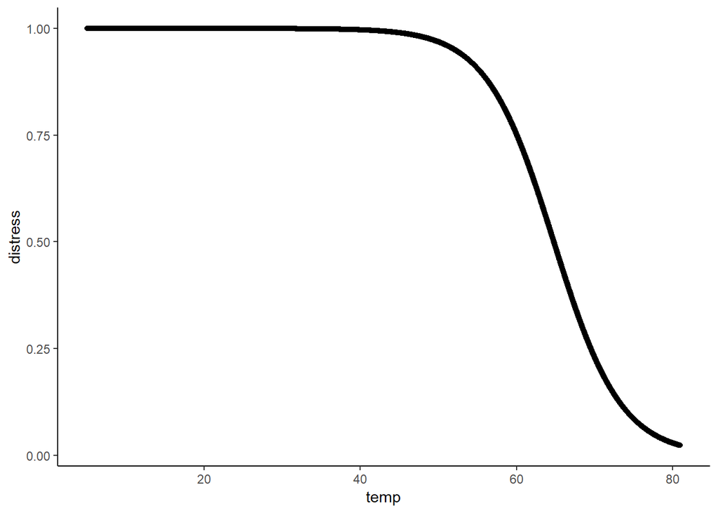

```r
plot2=ggplot(newdata, aes(x = temp, y = distress)) +
 geom_point()+
 theme_classic()
plot2
```